# Exploring the BRFSS data

## Setup

### Load packages

```r
library(ggplot2)
library(dplyr)
```

### Load data

```r
load("brfss2013.RData")
```

## Part 1: Data

Our dataset includes a lot of various features related to lifestyle such as health conditions, whether a person is an adult or not, their height/weight, how often do they take different medical tests and more.

The data is collected via both landline telephone and cellular telephone-based surveys from each of the 50 locations and participants are US citizens that are at least 18 years old. In the landline surveys, participants are randomly selected adults in a household. In the cellular telephone version, participants are adults, who are using cellular telephone and reside in a private residence or college housing.

The results are generalizable to the people in the respective states, since random sampling was used, however, we can’t establish any causal relationships since it is an observational study.

In total there are 491775 observations of 330 variables.

## Part 2: Research questions

**Research quesion 1:** There are quite a few books written about ‘rich’ and ‘successful’ people and their lifestyle. But now we have the data and can check it using various statistical tools.

Thus, the first question I’d like to examine is whether people with high level of education(those who graduated from college) and high level of household income(75000$ or more) are also more prone to take care of their physical health and check the ratio of people smoking in that group compared to the whole population.

**Research quesion 2:** The second question I’d like to look at how # of sleep hours affects concentration or remembering and general health.

My hypothesis is that there should be at least some correlation, although the required number of hours to sleep usually varies from person to person(e.g. older people typically sleep less).

**Research quesion 3:**

Here I’d like to check the relationship between physical exercises and body mass index. Although we can’t make any causal inferences out of the relationships between these 2 features, even if they exist, it is still an interesting issue to look into.

## Part 3: Exploratory data analysis

**Research quesion 1:**

So lets first grab the group of participants we’re going to examine, those with good education and high household income. So the 2 columns we need are called ‘educa’ and ‘income2’ let’s check what they look like for the first few observations using the `head()` function.

```r
brfss2013$educa %>% head
```

```
## [1] College 4 years or more (College graduate)
## [2] College 1 year to 3 years (Some college or technical school)
## [3] College 4 years or more (College graduate)
## [4] Grade 12 or GED (High school graduate)
## [5] College 4 years or more (College graduate)
## [6] College 4 years or more (College graduate)
## 6 Levels: Never attended school or only kindergarten ...
```

```r
brfss2013$income2 %>% head
```

```
## [1] Less than $75,000 $75,000 or more   $75,000 or more   Less than $75,000
## [5] Less than $50,000 $75,000 or more
## 8 Levels: Less than $10,000 Less than $15,000 ... $75,000 or more
```

Let’s check how many of these categories are there. It can be done using `levels()` function. And select the participants conforming to the highest level of income as well as the highest level of education using `filter()`.

```r
brfss2013$educa %>% levels
```

```
## [1] "Never attended school or only kindergarten"
## [2] "Grades 1 through 8 (Elementary)"
## [3] "Grades 9 though 11 (Some high school)"
## [4] "Grade 12 or GED (High school graduate)"
## [5] "College 1 year to 3 years (Some college or technical school)"
## [6] "College 4 years or more (College graduate)"
```

```r
brfss2013$income2 %>% levels
```

```
## [1] "Less than $10,000" "Less than $15,000" "Less than $20,000"
## [4] "Less than $25,000" "Less than $35,000" "Less than $50,000"
## [7] "Less than $75,000" "$75,000 or more"
```

```r
rich_and_educated = brfss2013 %>%
  filter(as.integer(income2) == 8, as.integer(educa) == 6)
```

Now let’s see how many such participans we got, and what’s the ratio of those participants/total participans. Use `round()` to limit the output to 2 decimal places.

```r
nrow(rich_and_educated)
```

```
## [1] 73800
```

```r
(nrow(rich_and_educated) / nrow(brfss2013)) %>%
  round(digits=2)
```

```
## [1] 0.15
```

We’re finally ready to check for various correlations by plotting the data. Let’s start with a histogram of the number of days our chosen participants don’t feel good about their physical health. For the sake of simplicity, we’ll use `hist()` function.

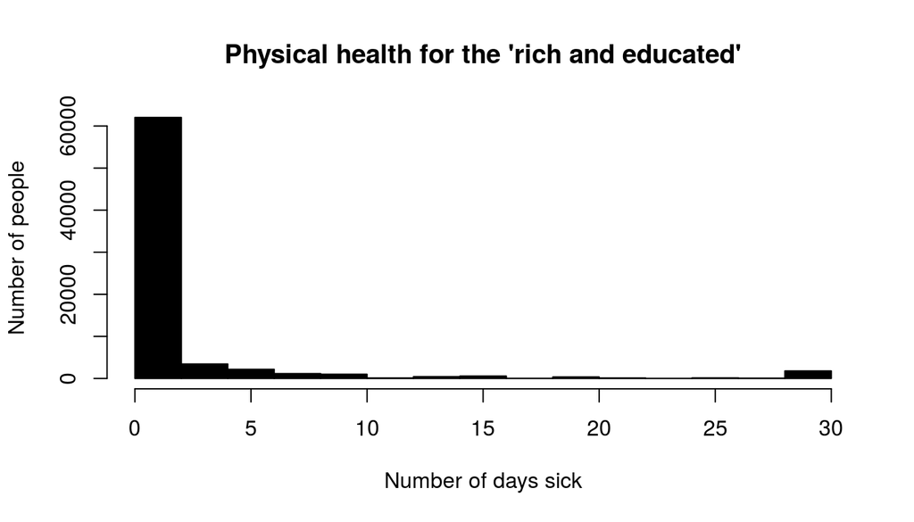

```r
hist(rich_and_educated$physhlth, main="Physical health for the 'rich and educated'", xlab="Number of days sick", ylab="Number of people", col="black", xlim=c(0, 30), breaks=15)
```

Apparently, most of our selected group, around 60 thousand participants have not been experiencing problems with their health when the data was collected. Let’s try the same thing but with the whole dataset.

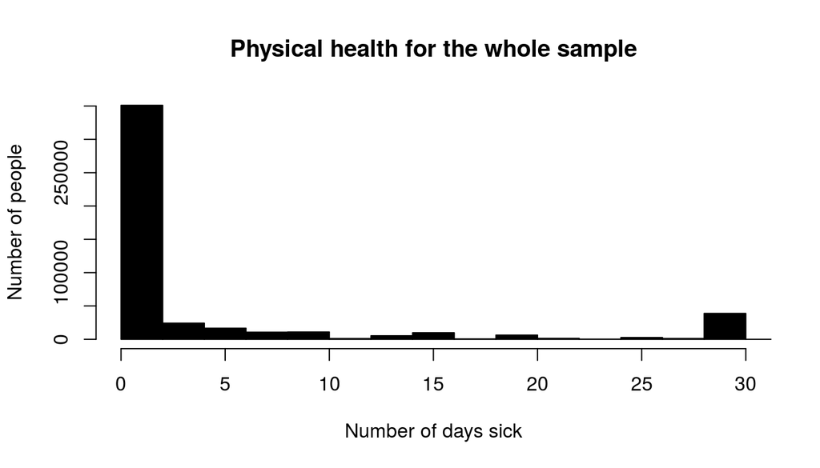

```r
hist(brfss2013$physhlth, main="Physical health for the whole sample", xlab="Number of days sick", ylab="Number of people", col="black", xlim=c(0, 30), breaks=30)
```

Well, the trend is still there. Perhaps, the variable representing physical health for the past 30 days is independent of the features we’ve chosen.

This time, let’s look at smoking ratios. Variable `smokday2’ is the one we’ll make use of. Let’s see what it represents.

```r
brfss2013$smokday2 %>% levels
```

```
## [1] "Every day"  "Some days"  "Not at all"
```

So 3 options, now let’s check for the distribution on the whole dataset as well as on our `rich_and_educated` slice. Let’s first make tables using `table()` function, as it will help us to manipulate the needed data.

```r
rich_and_educated_table = table(rich_and_educated$smokday2)
rich_and_educated_table
```

```
##
##  Every day  Some days Not at all
##       2302       1492      19375
```

```r
brfss2013_table = table(brfss2013$smokday2)
brfss2013_table
```

```
##
##  Every day  Some days Not at all
##      55163      21494     138135
```

If you look carefully, you might already notice some trend, but let’s create pie charts to make things more apparent. Calculate the percentages first using division and `sum()` function.

```r
percent_slice = round(100*rich_and_educated_table/sum(rich_and_educated_table), 1)
percent_slice
```

```
##
##  Every day  Some days Not at all
##        9.9        6.4       83.6
```

```r
percent_sample = round(100*brfss2013_table/sum(brfss2013_table), 1)
percent_sample
```

```
##
##  Every day  Some days Not at all
##       25.7       10.0       64.3
```

Now let’s move on and build the pie charts using `pie()` function. First, for the sliced data:

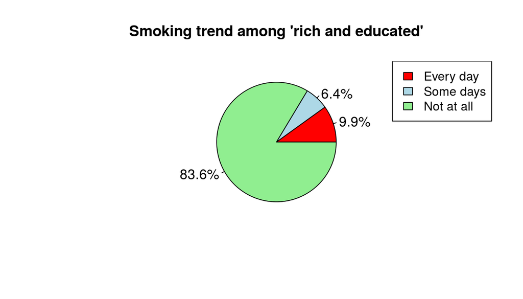

```r
cols = c("red", "lightblue", "lightgreen")
pielabels<- paste(percent_slice, "%", sep="")
legend_values = c("Every day", "Some days", "Not at all")

pie(rich_and_educated_table, main="Smoking trend among 'rich and educated'", col=cols, labels=pielabels, cex=1.1)
legend("topright", legend_values, fill=cols)
```

And then for the whole sample:

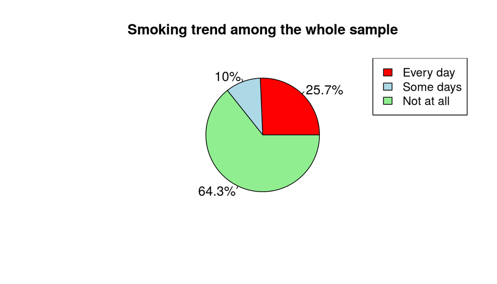

```r
pielabels<- paste(percent_sample, "%", sep="")
pie(brfss2013_table, main="Smoking trend among the whole sample", col=cols, labels=pielabels, cex=1.1)
legend("topright", legend_values, fill=cols)
```

There is a clear difference between our chosen group of participants vs. the whole sample. Let’s now move on to question 2 to explore this dataset further.

**Research quesion 2:**

So let’s have a look at the useful variables we have at our disposal. The most relevant ones seem to be `sleptim1`, `genhlth`, `physhlth` and `menthlth`. Let’s check the summary for these 4 variables using `summary()` function.

Before we do that, however, let’s slice our dataset, it’s more convenient to work with the subset, instead of selecting the columns out of the whole dataset every time.

```r
sleep_and_health = brfss2013[c("sleptim1", "genhlth", "physhlth", "menthlth")]
summary(sleep_and_health)
```

```
##     sleptim1            genhlth          physhlth         menthlth
##  Min.   :  0.000   Excellent: 85482   Min.   : 0.000   Min.   :   0.000
##  1st Qu.:  6.000   Very good:159076   1st Qu.: 0.000   1st Qu.:   0.000
##  Median :  7.000   Good     :150555   Median : 0.000   Median :   0.000
##  Mean   :  7.052   Fair     : 66726   Mean   : 4.353   Mean   :   3.383
##  3rd Qu.:  8.000   Poor     : 27951   3rd Qu.: 3.000   3rd Qu.:   2.000
##  Max.   :450.000   NA's     :  1985   Max.   :60.000   Max.   :5000.000
##  NA's   :7387                         NA's   :10957    NA's   :8627
```

According to the documentation, all the health features are supposed to have values 0-30 which represents the number of days that a person was in that state of health. And `sleptim1` is supposed to be 0-24 representing the average number of hours of sleep per day. However, in our dataset we can see that max for `sleptim1` is 450, which already doesn’t look right.

Not only that, but we can also notice that `physhlth` and `menthlth` has maximum values above 30, which is also a nonsense.

Let’s remove all the invalid data and build a table to see what we get. Create a few helper variables on the way and construct a new slice. Also, lets get rid of rows containing NA values.

```r
brfss2013$sleptim1_clean = apply(brfss2013['sleptim1'], 1, function(x) ifelse (x <= 24, x, NA))
brfss2013$physhlth_clean = apply(brfss2013['physhlth'], 1, function(x) ifelse (x <= 30, x, NA))
brfss2013$menthlth_clean = apply(brfss2013['menthlth'], 1, function(x) ifelse (x <= 30, x, NA))
sleep_and_health = brfss2013[c("sleptim1_clean", "genhlth", "physhlth_clean", "menthlth_clean")] %>% na.omit
summary(sleep_and_health)
```

```
##  sleptim1_clean        genhlth       physhlth_clean   menthlth_clean
##  Min.   : 1.000   Excellent: 83786   Min.   : 0.000   Min.   : 0.000
##  1st Qu.: 6.000   Very good:155135   1st Qu.: 0.000   1st Qu.: 0.000
##  Median : 7.000   Good     :143251   Median : 0.000   Median : 0.000
##  Mean   : 7.051   Fair     : 60562   Mean   : 4.239   Mean   : 3.322
##  3rd Qu.: 8.000   Poor     : 24759   3rd Qu.: 3.000   3rd Qu.: 2.000
##  Max.   :24.000                      Max.   :30.000   Max.   :30.000
```

Ok, this command was a bit too slow, but seems to work. Now that we got rid of the bad values, let’s construct a table to see if there are any patterns.

```r
sleep_health_table = table(brfss2013$sleptim1_clean, brfss2013$genhlth)
sleep_health_table
```

```
##
##      Excellent Very good  Good  Fair  Poor
##   0          1         0     0     0     0
##   1         26        23    58    50    71
##   2         72       100   234   282   375
##   3        254       425   824   985   978
##   4       1212      2291  4069  3736  2886
##   5       3661      8121 10858  7161  3489
##   6      16013     33512 34838 15687  5830
##   7      28824     55255 41699 12893  3419
##   8      28478     47099 42760 16685  5476
##   9       4260      7429  7308  3376  1315
##   10      1466      2576  3872  2649  1467
##   11        91       163   254   187   133
##   12       318       612  1049   917   756
##   13        26        31    49    55    38
##   14        34        55   128   104   124
##   15        21        40   106    92   104
##   16        34        64   115    82    69
##   17         9         3     9     4    10
##   18        11        18    38    34    62
##   19         1         4     3     1     4
##   20         2         9    16    19    18
##   21         0         0     2     0     1
##   22         2         1     3     2     2
##   23         0         0     0     1     3
##   24         6         2     7    10     9
```

Let’s try constructing a scatterplot.

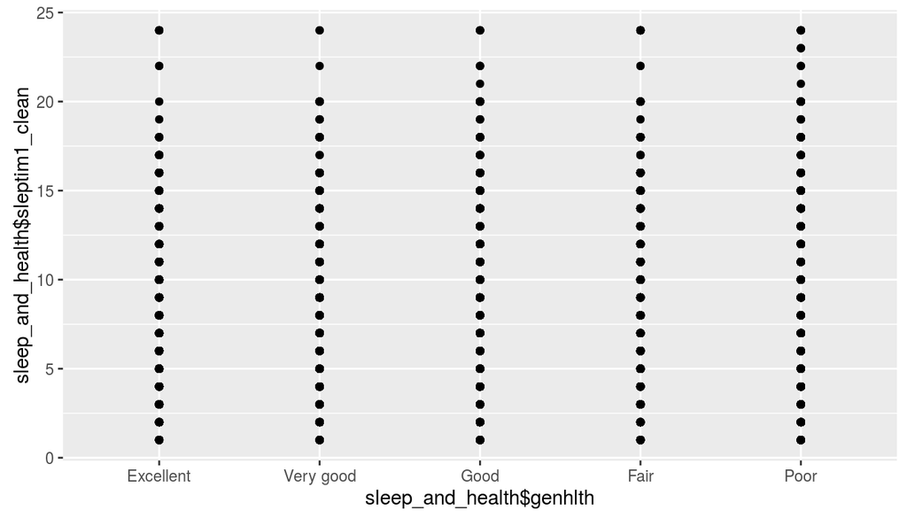

```r
ggplot(sleep_and_health, aes(x = sleep_and_health$genhlth, y = sleep_and_health$sleptim1_clean)) + geom_point()
```

Ok, this does not really help much. Let’s separate our data by the hours of sleep, take 6-9 hours, less than that and more than that.

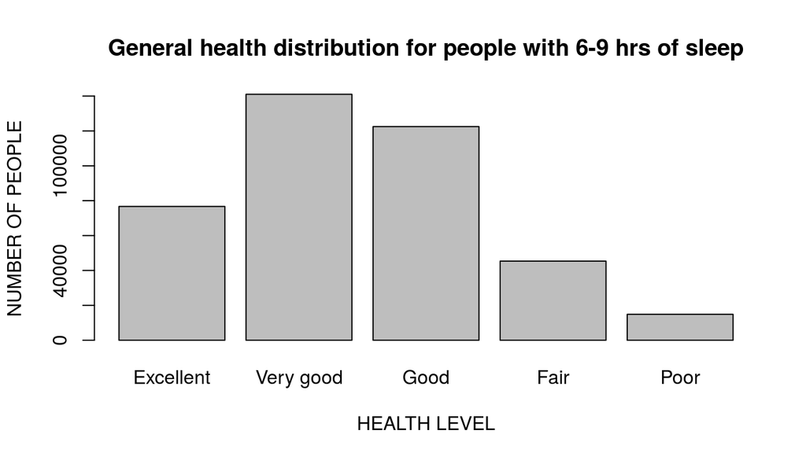

```r
sleep6_9 = sleep_and_health %>% filter(sleptim1_clean >= 6 & sleptim1_clean <= 9)
plot(sleep6_9$genhlth,
        main="General health distribution for people with 6-9 hrs of sleep",
        xlab="HEALTH LEVEL", ylab="NUMBER OF PEOPLE")
```

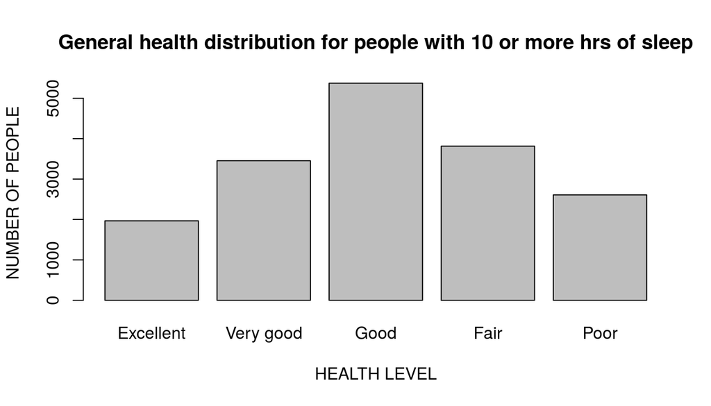

```r
sleep10_or_more = sleep_and_health %>% filter(sleptim1_clean >= 10)
plot(main="General health distribution for people with 10 or more hrs of sleep", sleep10_or_more$genhlth, xlab="HEALTH LEVEL", ylab="NUMBER OF PEOPLE")
```

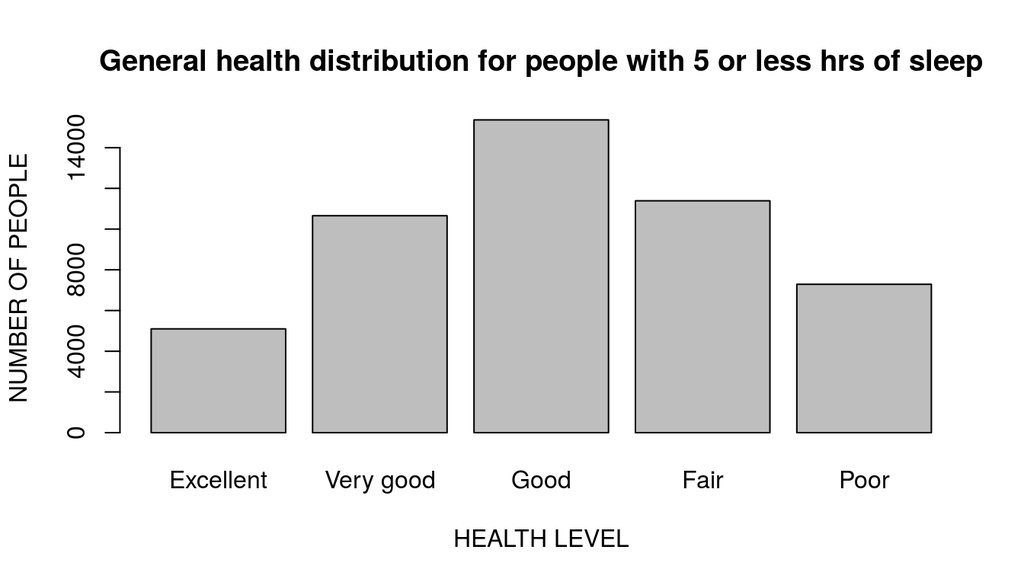

```r
sleep5_or_less = sleep_and_health %>% filter(sleptim1_clean <= 5)
plot(main="General health distribution for people with 5 or less hrs of sleep", sleep5_or_less$genhlth, xlab="HEALTH LEVEL", ylab="NUMBER OF PEOPLE")
```

Comparing these 3 plots, we can see that the distribution is leaning towards left when the sleep hours are somewhat adequate(6-9). But the correlation is not that dramatic.

Let’s now have a look at other health parameters.

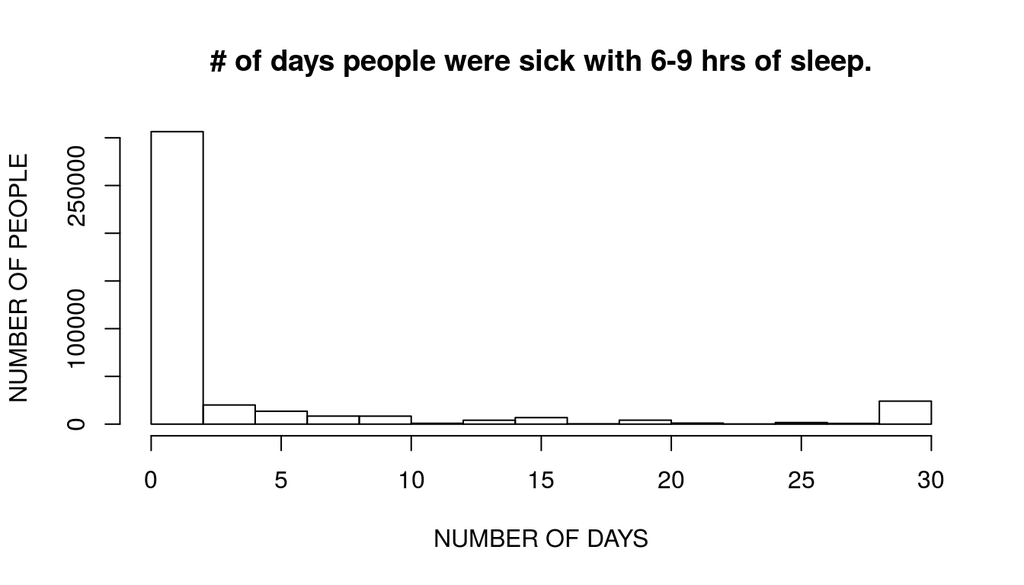

```r
hist(sleep6_9$physhlth_clean,
        main="# of days people were sick with 6-9 hrs of sleep.",
        xlab="NUMBER OF DAYS", ylab="NUMBER OF PEOPLE")
```

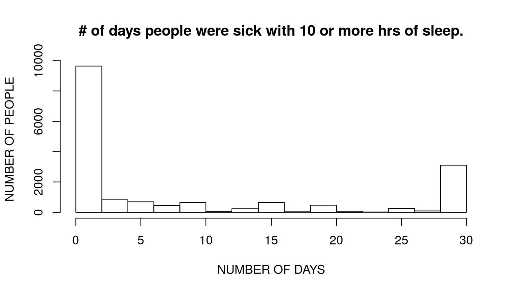

```r
hist(sleep10_or_more$physhlth_clean,
        main="# of days people were sick with 10 or more hrs of sleep.",
        xlab="NUMBER OF DAYS", ylab="NUMBER OF PEOPLE")
```

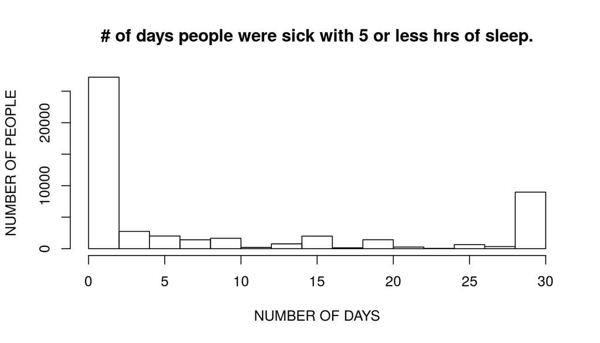

```r
hist(sleep5_or_less$physhlth_clean,
        main="# of days people were sick with 5 or less hrs of sleep.",
        xlab="NUMBER OF DAYS", ylab="NUMBER OF PEOPLE")
```

We can see a bit of a trend there at the mark of 30 days. Finally, let’s have a look at mental health.

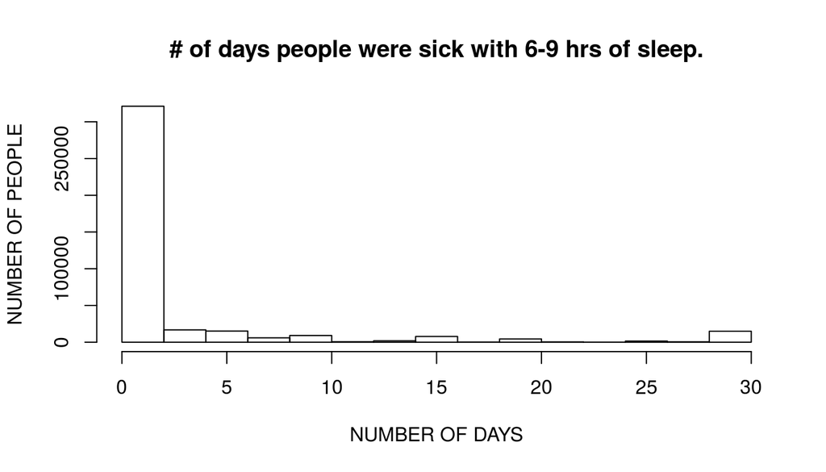

```r
hist(sleep6_9$menthlth_clean,
        main="# of days people were sick with 6-9 hrs of sleep.",
        xlab="NUMBER OF DAYS", ylab="NUMBER OF PEOPLE")
```

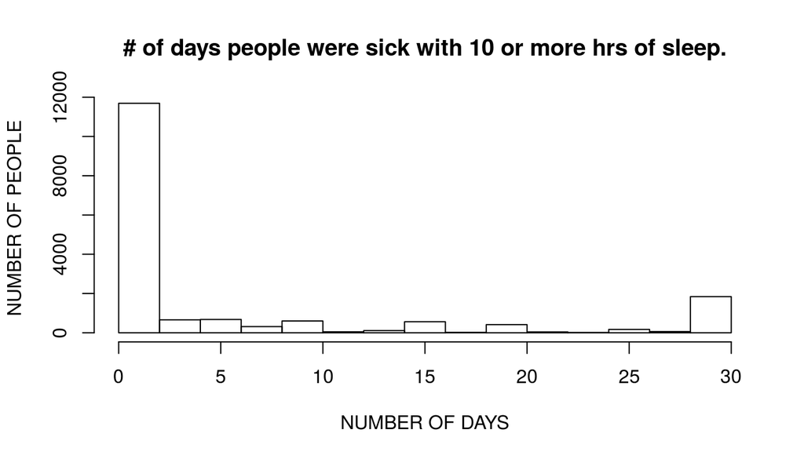

```r
hist(sleep10_or_more$menthlth_clean,
        main="# of days people were sick with 10 or more hrs of sleep.",
        xlab="NUMBER OF DAYS", ylab="NUMBER OF PEOPLE")
```

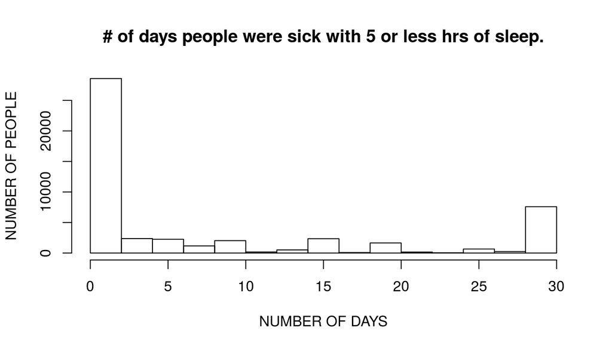

```r
hist(sleep5_or_less$menthlth_clean,
        main="# of days people were sick with 5 or less hrs of sleep.",
        xlab="NUMBER OF DAYS", ylab="NUMBER OF PEOPLE")
```

**Research quesion 3:**

As usual, we start with identifying useful variables. The obvious ones are `htm4` which is ‘Computed Height In Meters’ and `wtkg3` which is ‘Computed Weight In Kilograms’ according to the documentation. To make things simpler, we could use BMI(body mass index) instead. Let’s see if we already have such a variable at our disposal.

It turns out there is a variable called `X_bmi5cat` which is exactly what we need. Let’s have a look.

```r
brfss2013$X_bmi5cat %>% summary
```

```
##   Underweight Normal weight    Overweight         Obese          NA's
##          8267        154898        167084        134799         26727
```

Now let’s see which useful variables are present to figure out the information about physical exercises.

Again, let’s use a pre-comupted variable called `X_totinda` which gives this information to us in a yes/no format.

```r
brfss2013$X_totinda %>% summary
```

```
##                Had physical activity or exercise
##                                           332461
## No physical activity or exercise in last 30 days
##                                           125280
##                                             NA's
##                                            34034
```

Finally, let’s do some visualizations. We’ll create 2 auxilliary datasets: one with Underweight + Normal Weight participants, and the other with Overweight and Obese for easier analysis.

```r
underweight_normal = brfss2013 %>% filter(X_bmi5cat == 'Underweight' | X_bmi5cat == 'Normal weight')
overweight_obese = brfss2013 %>% filter(X_bmi5cat == 'Overweight' | X_bmi5cat == 'Obese')
```

And now let’s see a percentage or a probability of each of the events for these 2 groups. Starting with underweight and normal weight group.

```r
stats_underweight_normal = underweight_normal$X_totinda %>% summary
```

What’s the probability of a person exercising out of everyone conforming to this group? Let’s take the total where we will exclude the NAs. There is probably a better way to do it though.

```r
total_underweight_normal = (stats_underweight_normal[1] + stats_underweight_normal[2])
(stats_underweight_normal[1] / total_underweight_normal) %>% round(digits=2)
```

```
## Had physical activity or exercise
##                              0.78
```

What’s the probability of a person not exercising out of everyone conforming to this group?

```r
(stats_underweight_normal[2] / total_underweight_normal) %>% round(digits=2)
```

```
## No physical activity or exercise in last 30 days
##                                             0.22
```

And as expected, we get the complement, `1 - 0.78`.

Now let’s move on to the overweight and obese group.

```r
stats_overweight_obese = overweight_obese$X_totinda %>% summary
```

What’s the probability of a person exercising out of everyone conforming to this group?

```r
total_overweight_obese = (stats_overweight_obese[1] + stats_overweight_obese[2])
(stats_overweight_obese[1] / total_overweight_obese) %>% round(digits=2)
```

```
## Had physical activity or exercise
##                               0.7
```

What’s the probability of a person not exercising out of everyone conforming to this group?

```r
(stats_overweight_obese[2] / total_overweight_obese) %>% round(digits=2)
```

```
## No physical activity or exercise in last 30 days
##                                              0.3
```